# Applied Computational Methods for Social Sciences

Lecture 11: Fundamentals of Mapping — Points, Lines, Polygons, and Choropleth Maps

Bogdan G. Popescu

bogdan.popescu@johncabot.edu

John Cabot University

## What You’ll Learn Today

1. Mapping **points, lines, and polygons** with `ggplot2` and `sf`
2. Building **choropleth maps** step by step
3. Classification schemes: **quantile, interquartile, standard deviation, and outlier** maps
4. Using **histograms** to choose sensible breaks
5. Arranging maps and legends for presentation

By the end, you’ll be able to design honest, readable statistical maps.

## Mapping

Previously, we looked at using ggplot to plot different objects

We will go over mapping objects once again.

## Mapping

First, download all the files and put them in the relevant folder:

- [Geodatabase with features](https://www.dropbox.com/s/j7yxk9xqpzw1mcx/selection.gdb.zip?dl=0)
- [Restaurants dataset](https://www.dropbox.com/scl/fi/81tptv295c9jvwifb4mvw/restaurant.geojson?rlkey=z6jp4ohzxz6muw00f31ev8854&dl=0)
- [Life Expectancy Data](https://www.dropbox.com/scl/fi/mov6aepbhht7i5tq627ph/life-expectancy.csv?rlkey=i78qnrk5hbl8hsqcl2igzdyuz&dl=0)
- [World Shapefile](https://www.dropbox.com/scl/fo/sicrsek31pim4nb3pzeea/h?rlkey=ooqm9kaz036baa8fi6dfaxei6&dl=0)

## Your folder

Note that `selection.gdb` and `world_shp` should be separate folders

## Your folder

Note that `selection.gdb` and `world_shp` should be separate folders

## Mapping

We will first map points, lines, and polygons

We will then map then together

We will then make a map that is visually appealing and which contains a variety of elements and options

## Mapping

This is how we first read our data:

```r
#Step1: Loading the libraries
library(sf)
library(ggplot2)

#Step2: Reading the lines
gis_osm_roads <- st_read(dsn="./data/selection.gdb",
                         layer="gis_osm_roads", quiet = T)

#Step3: Reading the polygons
gis_buildings <- st_read(dsn="./data/selection.gdb",
                         layer="gis_osm_buildings", quiet = T)

#Step4: Reading points
restaurants <- st_read("./data/restaurant.geojson", quiet = T)
restaurants<-subset(restaurants, select = c(name, addr.street))
restaurants2<-subset(restaurants, !is.na(restaurants$name) | !is.na(restaurants$addr.street) )
```

## Mapping lines

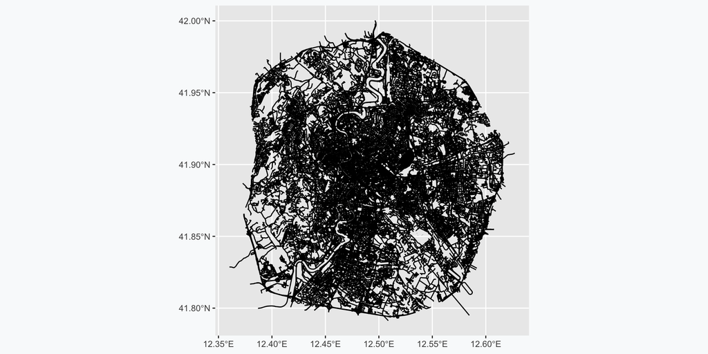

```r
ggplot()+
  geom_sf(data=gis_osm_roads)
```

## Mapping polygons

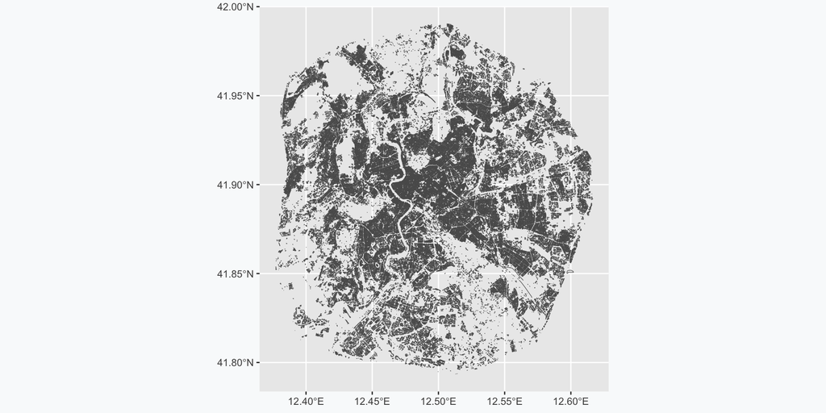

```r
ggplot()+
  geom_sf(data=gis_buildings)
```

## Mapping points

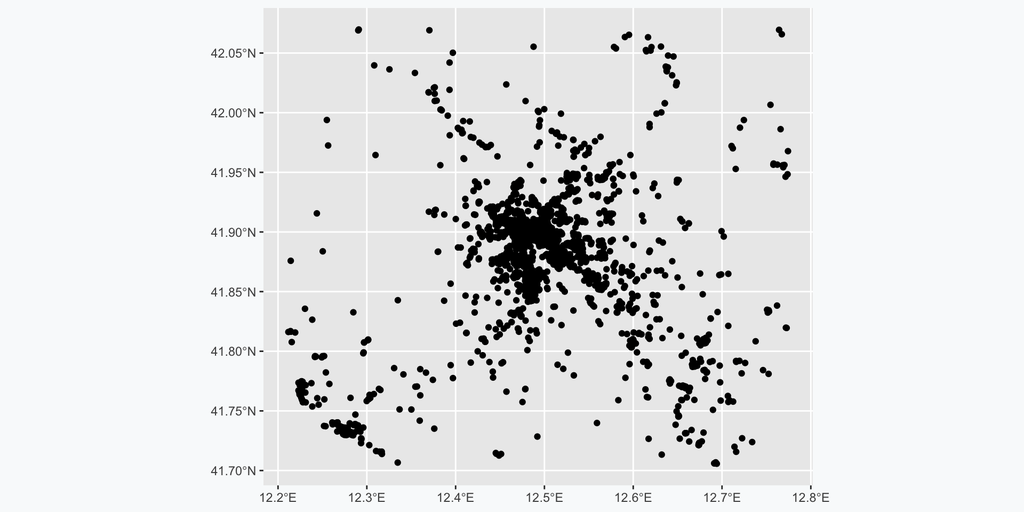

```r
ggplot()+
  geom_sf(data=restaurants2)
```

## Mapping Everything

As you might have guessed, this is GIS data covering central Rome

## Mapping Everything

This is how can can make that map.

Part one is about identifying a relevant zoom level.

```r
#Step1: Loading the relevant library
library(stringr)
#Step2: Choosing a geographuc point
jcu <- subset(gis_buildings, name=="John Cabot University - Tiber Campus")
#Step3: Extracting the centroid of the geometry
jcu$lonlat<-st_centroid(st_geometry(jcu))
#Step4: Splitting the name of the centroid variable into two
jcu[c('lon_x', 'lat_y')]<-str_split_fixed(jcu$lonlat, ",", 2)
#Step5: Making the variables numeric and removing extraneous particles
jcu$lat_y<-as.numeric(str_replace(jcu$lat_y, "\\)", ""))
jcu$lon_x<-as.numeric(str_replace(jcu$lon_x, "c\\(", ""))
#Step6: Deciding on an error
error<-0.008
#Step7: Taking the min/max lat/lon and adding/subtracting error
min_lon_x<-min(jcu$lon_x-error)
max_lon_x<-max(jcu$lon_x+error)

min_lat_y<-min(jcu$lat_y-error)
max_lat_y<-max(jcu$lat_y+error)
```

## Mapping Everything

This how can can make that map.

Part two is about the map itself:

```r
ggplot() +
  # Mapping roads
  geom_sf(data = gis_osm_roads, aes(color = "Roads"), size = 0.8, alpha = 0.5, show.legend = "line") +
  # Mapping buildings
  geom_sf(data = gis_buildings, aes(fill = "Buildings"), alpha = 0.5) +
  # Mapping restaurants
  geom_sf(data = restaurants2, aes(shape = "Restaurants"), color="red", fill="red", show.legend = "point") +
  # Making buildings orange
  scale_fill_manual(name = "",
                    values = c("Buildings" = "orange"),
                    guide = guide_legend(override.aes = list(linetype = c("blank"),
                                                             shape = NA))) +
  # Making roads blue
  scale_color_manual(name = "",
                     values = c("Roads" = "steelblue"),
                     guide = guide_legend(override.aes = list(linetype = c("solid"),
                                                              shape = c(NA)))) +
  # Making restaurants diamonds
  scale_shape_manual(name = "",
                     values = c("Restaurants" = 23),
                     guide = guide_legend(override.aes = list(linetype = c("blank"))))+
  theme_bw() +
  # Zoom coordinates
  coord_sf(xlim = c(min_lon_x - error, max_lon_x + error),
           ylim = c(min_lat_y - error, max_lat_y + error))+
  # Adding scale
  ggspatial::annotation_scale(location = 'tr')+
  # Adding North arrow
  ggspatial::annotation_north_arrow(which_north = "true", location = "bl")
```

[output not shown]

## Mapping Everything

This how can can make that map.

## Mapping Everything

As you might imagine, there are are variety of options to represent points, lines, and polygons

At the most basic level, you can change the symbols for points, the color for lines and shape of polygons, the fill color for polygons, etc.

## Choropleth Maps

- The first component of Spatial Data is simply making maps
- A choropleth map is a thematic map used to represent statistical data, where regions are colored in relation to a data variable
- Here is for example what avearge life expectancy from 1900 untill the present day looks like

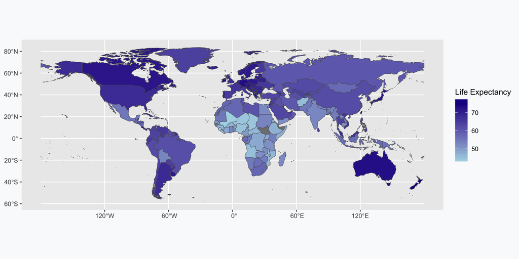

## Mapping Spatial Data

This how we can make this map.

First, we need to download the life expectancy data and world polygons:

- Dataset 1 - [Life expectancy data](https://www.dropbox.com/scl/fi/mov6aepbhht7i5tq627ph/life-expectancy.csv?rlkey=i78qnrk5hbl8hsqcl2igzdyuz&dl=0)
- Dataset 2 - [World polygons](https://www.dropbox.com/scl/fo/sicrsek31pim4nb3pzeea/h?rlkey=ooqm9kaz036baa8fi6dfaxei6&dl=0)

Place it in the data folder within the relevant week.

## Mapping Spatial Data

This is the code to obtain the map.

```r
#Step1: Loading libraries
library("dplyr")
library("sf")
library("ggplot2")

#Step2: Loading the data
life_expectancy <- read.csv(file = './data/life-expectancy.csv')

#Step3: Subsetting the data above the year 1900
life_expectancy<-subset(life_expectancy, Year>1900)

#Step4: Calculating average life expectancy by county
life_expectancy2<-life_expectancy%>%
  group_by(Code, Entity)%>%
  summarize(life_expectancy=mean(Life.expectancy.at.birth..historical.))

#Step5: Removing countries with not code
life_expectancy3<-subset(life_expectancy2, life_expectancy2$Code!="")

#Step6: Reading shape files
world <- read_sf(dsn = "./data/world_shp/world.shp")
merged<-left_join(world, life_expectancy3, by = c("adm0_a3" = "Code"))

#Step7: Mapping
ggplot() +
    geom_sf() +
    geom_sf(data = merged, aes(fill = life_expectancy))+
    scale_fill_gradient(name = "Life Expectancy", low = "lightblue", high = "darkblue")
```

## Mapping Spatial Data

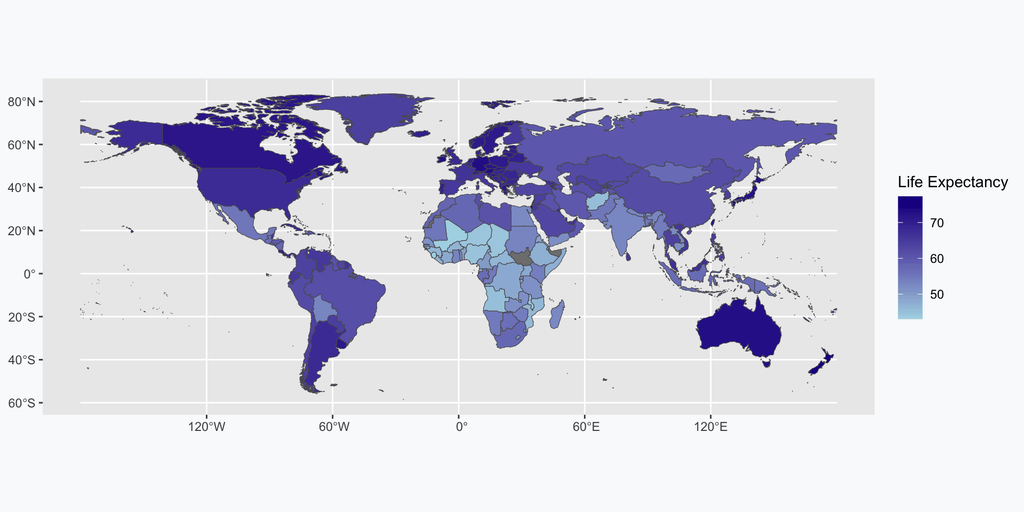

What we can see here are the black polygons which are filled in blue.

- Darker shades of blue indicate higher life expectancy.
- Lighter shades of blue indicate lower life expectancy.

## Mapping Spatial Data

It turns out that that this color scheme is not the best to make choropleth maps.

## Mapping Spatial Data: magma

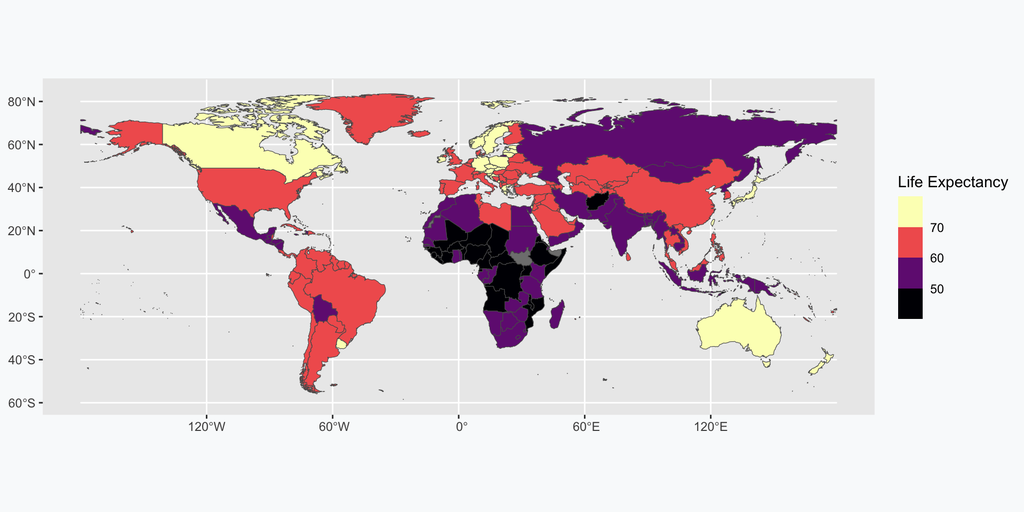

```r
ggplot() +
    geom_sf() +
    geom_sf(data = merged, aes(fill = life_expectancy))+
    scale_fill_viridis_b(name = "Life Expectancy", option = "magma")
```

## Mapping Spatial Data: inferno

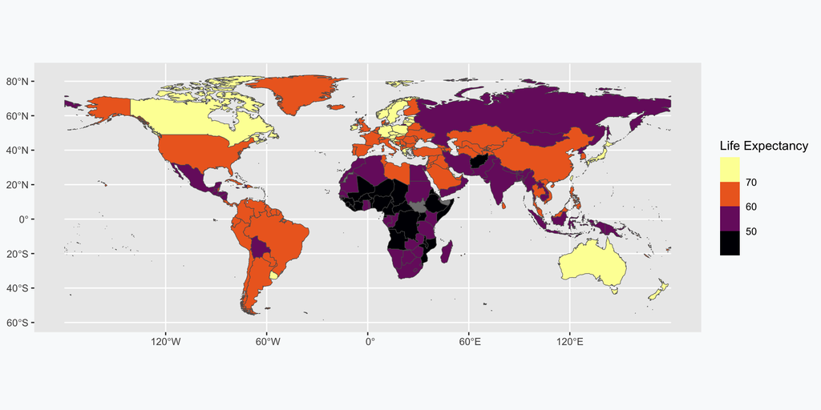

```r
ggplot() +
    geom_sf() +
    geom_sf(data = merged, aes(fill = life_expectancy))+
    scale_fill_viridis_b(name = "Life Expectancy", option = "inferno")
```

## Mapping Spatial Data: plasma

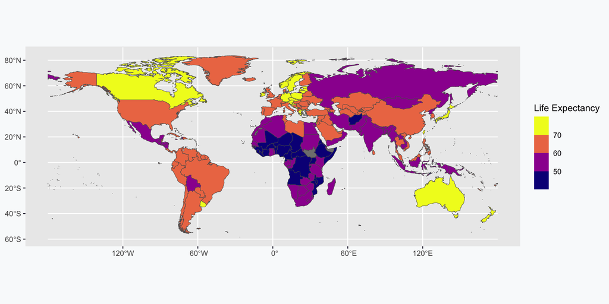

```r
ggplot() +
    geom_sf() +
    geom_sf(data = merged, aes(fill = life_expectancy))+
    scale_fill_viridis_b(name = "Life Expectancy", option = "plasma")
```

## Mapping Spatial Data: viridis

```r
ggplot() +
    geom_sf() +
    geom_sf(data = merged, aes(fill = life_expectancy))+
    scale_fill_viridis_b(name = "Life Expectancy", option = "viridis")
```

[output not shown]

## Mapping Spatial Data: cividis

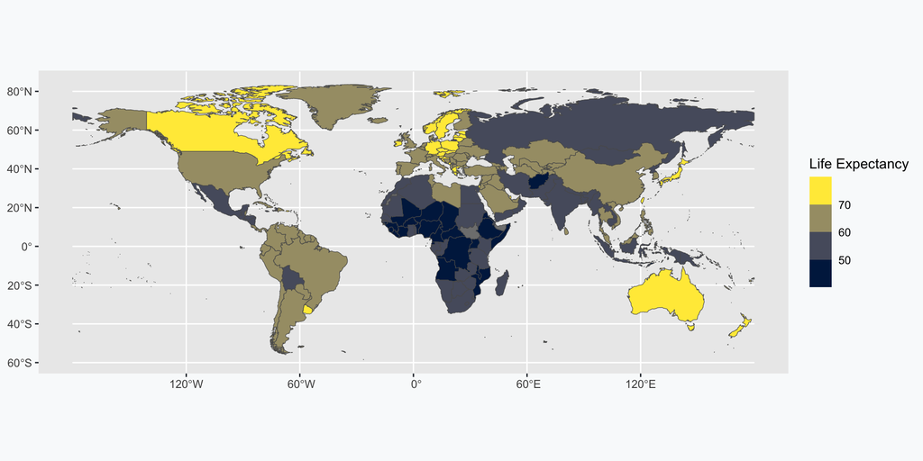

```r
ggplot() +
    geom_sf() +
    geom_sf(data = merged, aes(fill = life_expectancy))+
    scale_fill_viridis_b(name = "Life Expectancy", option = "cividis")
```

## Mapping Spatial Data: rocket

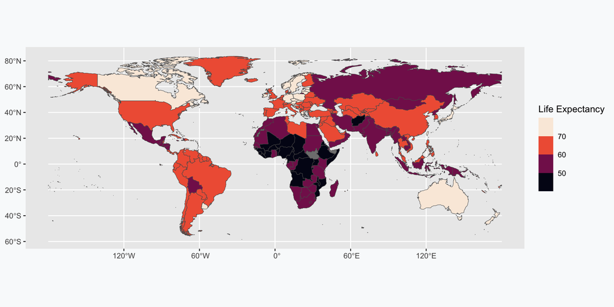

```r
ggplot() +
    geom_sf() +
    geom_sf(data = merged, aes(fill = life_expectancy))+
    scale_fill_viridis_b(name = "Life Expectancy", option = "rocket")
```

## Mapping Spatial Data: mako

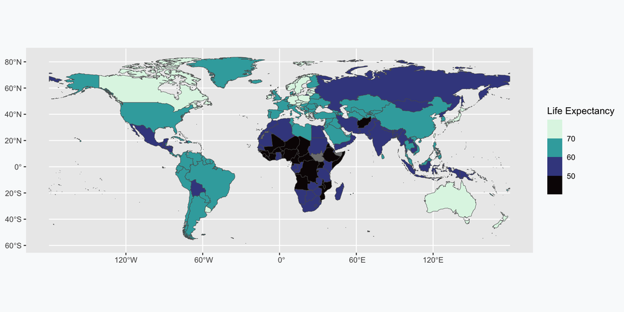

```r
ggplot() +
    geom_sf() +
    geom_sf(data = merged, aes(fill = life_expectancy))+
    scale_fill_viridis_b(name = "Life Expectancy", option = "mako")
```

## Mapping Spatial Data: turbo

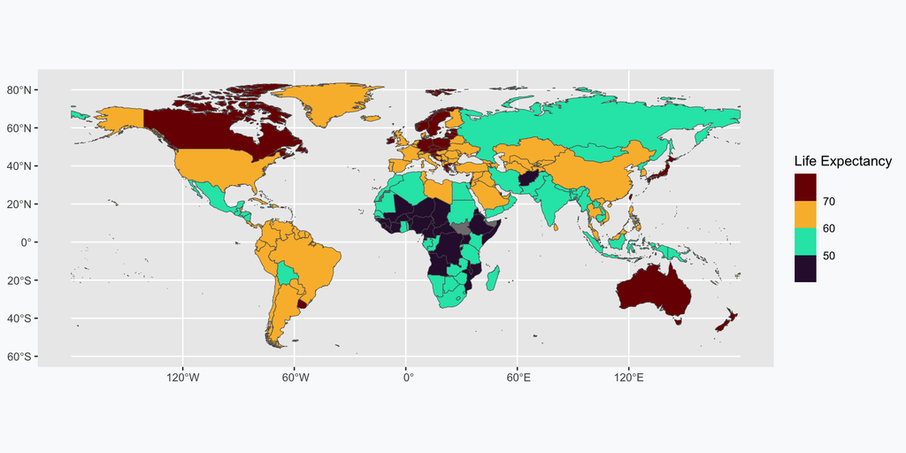

```r
ggplot() +
    geom_sf() +
    geom_sf(data = merged, aes(fill = life_expectancy))+
    scale_fill_viridis_b(name = "Life Expectancy", option = "turbo")
```

## Statistical Maps

- The most common maps are choropleth maps, which show variability of a variable over one region
- It is however important to understand how the assignment to colors is made

## Statistical Maps

- In the choropleth map above, we see that the continuous variable, which is life expectancy, got reduced to discrete entities.
- Making values discrete values from continuous means that we are assigning those values to bins.
- For example, all countries that have and average life a life expectancy of 70 to 80, get assigned to one color.

## Statistical Maps

We can create a map with colors that follow the distribution of our data.

Let us first create a histogram with our life expectancy data.

The following should be 10 equal breaks (bins) for the histogram.

```r
library(classInt)
# Creating 10 equal intervals within the variable
clint <- classIntervals(merged$life_expectancy, style = "equal", n = 10)$brks
clint
```

```
 [1] 43.07639 46.49403 49.91167 53.32931 56.74694 60.16458 63.58222 66.99986
 [9] 70.41750 73.83514 77.25278
```

## Statistical Maps

The next step is to use ggplot to create the histogram

```r
p2<-ggplot(merged, aes(life_expectancy)) +
  #including breaks for the histogram
  geom_histogram(breaks = clint, col="white")+
  #indicating min, median, and max on x-axis
  scale_x_continuous(breaks = c(min(clint), median(clint), max(clint)), position = "top") +
  #removing all the ticks on the y axis
  scale_y_continuous(labels = NULL, breaks = NULL)+
  #removing the x and y labels
  ylab(NULL) +xlab(NULL)+
  #flipping coordinates: x become y and y becomes x
  coord_flip()+
  theme(plot.margin = margin(0.1,0,0,0.1, "in"),
         axis.text = element_text(colour = "grey"),
         panel.background = element_blank())
p2
```

## Statistical Maps

This code produces the following graph:

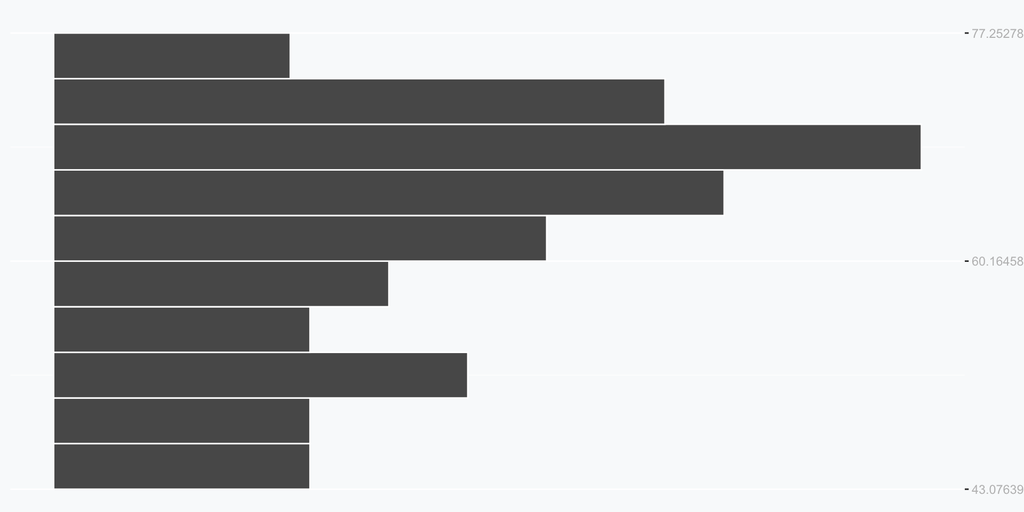

## Statistical Maps

This is how a regular histogram differs from the one we just produced

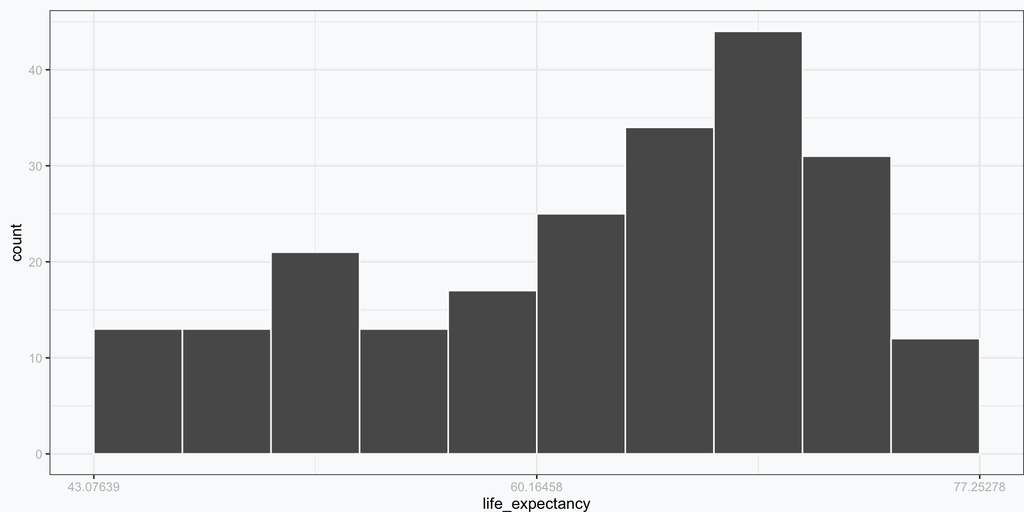

```r
p2<-ggplot(merged, aes(life_expectancy)) +
  #including breaks for the histogram
  geom_histogram(breaks = clint, col="white")+
  #indicating min, median, and max on x-axis
  # position = "top" ensures that the breaks and labels align with the x-axis at the top.
  scale_x_continuous(breaks = c(min(clint), median(clint), max(clint)), position = "bottom") +
  #removing all the ticks on the y axis
  #scale_y_continuous(labels = NULL, breaks = NULL)+
  #removing the x and y labels
  #ylab(NULL) +xlab(NULL)+
  #flipping coordinates: x become y and y becomes x
  #coord_flip()+
  theme_bw()+
  theme(plot.margin = margin(0.1,0,0,0.1, "in"),
         axis.text = element_text(colour = "grey"),
         panel.background = element_blank())
p2
```

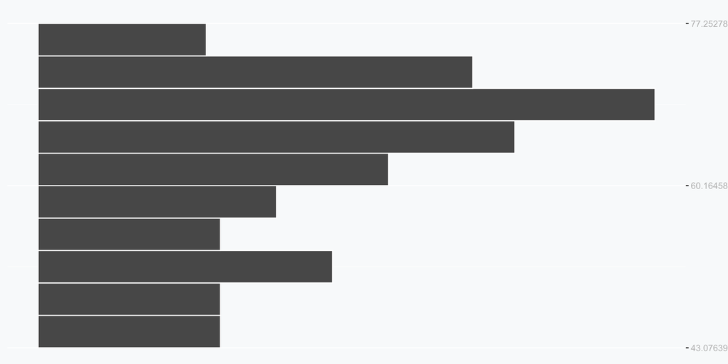

```r
p2<-ggplot(merged, aes(life_expectancy)) +
  #including breaks for the histogram
  geom_histogram(breaks = clint, col="white")+
  #indicating min, median, and max on x-axis
  # position = "top" ensures that the breaks and labels align with the x-axis at the top.
  scale_x_continuous(breaks = c(min(clint), median(clint), max(clint)), position = "top") +
  #removing all the ticks on the y axis
  scale_y_continuous(labels = NULL, breaks = NULL)+
  #removing the x and y labels
  ylab(NULL) +xlab(NULL)+
  #flipping coordinates: x become y and y becomes x
  coord_flip()+
  theme(plot.margin = margin(0.1,0,0,0.1, "in"),
         axis.text = element_text(colour = "grey"),
         panel.background = element_blank())
p2
```

## Statistical Maps

We can use the same histogram to create colors for ggplot.

But we first need to do some transformations:

## Statistical Maps

We can use the same histogram to create colors for ggplot.

But we first need to do some transformations:

```r
clint <- classIntervals(merged$life_expectancy, style = "equal", n = 10)$brks
```

## Statistical Maps

We can use the same histogram to create colors for ggplot.

But we first need to do some transformations:

```r
clint <- classIntervals(merged$life_expectancy, style = "equal", n = 10)$brks
clint
```

```
 [1] 43.07639 46.49403 49.91167 53.32931 56.74694 60.16458 63.58222 66.99986
 [9] 70.41750 73.83514 77.25278
```

## Statistical Maps

We can use the same histogram to create colors for ggplot.

But we first need to do some transformations:

```r
#Identifying vector length
number_values<-length(clint)
```

## Statistical Maps

We can use the same histogram to create colors for ggplot.

But we first need to do some transformations:

```r
#Identifying vector length
number_values<-length(clint)
number_values
```

```
[1] 11
```

## The Map

This is the map that we want to obtain:

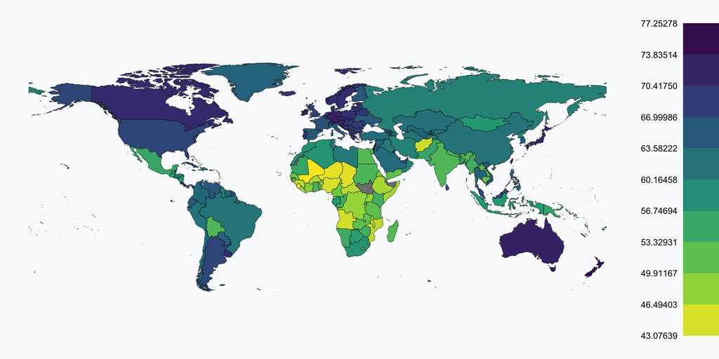

## The Map

The following code allows us to obtain the map

```r
library(ggplot2)
library(viridis)

p1<-ggplot(merged, aes(fill = life_expectancy)) +
  geom_sf() +
  theme_void() +
  scale_fill_viridis_c(option = "viridis",
                       direction = -1, # Use -1 for reverse color order
                       breaks = clint,
                       guide = guide_coloursteps(even.steps = FALSE,
                                                 show.limits = FALSE,
                                                 title = NULL,
                                                 barheight = unit(0.87, "npc"), # Relative to plot height
                                                 barwidth = unit(0.05, "npc"),  # Relative to plot width
                                                 label.position = "left"))
```

## The Map with the Histogram

```r
library(gridExtra)
grid.arrange(p1, p2,layout_matrix=rbind(c(1,1,1,2)))
```

[output not shown]

## The Map with the Histogram

```r
library(gridExtra)
pic<-grid.arrange(p1, p2,layout_matrix=rbind(c(1,1,1,2)))
```

Note that you need to add an option to the chunk to get the map and histogram alligned:

````markdown
```{r , fig.width = 6.5, fig.height=2.4}
library(gridExtra)
pic<-grid.arrange(p1, p2,layout_matrix=rbind(c(1,1,1,2)))
```
````

## The Map with the Histogram

```r
library(gridExtra)
grid.arrange(p1, p2,layout_matrix=rbind(c(1,1,1,2)))
```

[output not shown]

Note that you need to add an option to the chunk to get the map and histogram alligned:

````markdown
```{r , fig.width = 6.5, fig.height=2.4}
library(gridExtra)
pic<-grid.arrange(p1, p2,layout_matrix=rbind(c(1,1,1,2)))
```
````

To save the picture as a jpeg, you need to run the following code:

```r
#The following code is to save the map in your working folder
pic<-grid.arrange(p1, p2,layout_matrix=rbind(c(1,1,1,2)))
ggsave("./figx.jpg", plot = pic, height = 6, width = 20, units = "cm", dpi = 300)
```

## Quantile Maps

- An equal interval map benefits from its intuitiveness
- It may not be well suited for a type of data, that is not uniformly distributed
- **Quantiles** define ranges of values that have equal number of observations.

## Quantile Maps

These are the steps to produce the same map:

## Quantile Maps

These are the steps to produce the same map:

```r
#This to produce the interval
clint <- classIntervals(merged$life_expectancy, style = "quantile", n = 6)$brks
```

## Quantile Maps

These are the steps to produce the same map:

```r
#This to produce the interval
clint <- classIntervals(merged$life_expectancy, style = "quantile", n = 6)$brks
clint
```

```
[1] 43.07639 52.02222 59.86389 64.41389 68.03182 70.78068 77.25278
```

## Quantile Maps

These are the steps to produce the same map:

```r
#This to produce the interval
clint <- classIntervals(merged$life_expectancy, style = "quantile", n = 6)$brks
#Identifying vector length
number_values<-length(clint)
number_values
```

```
[1] 7
```

## Quantile Maps

These are the steps to produce the same map:

```r
#This to produce the interval
clint <- classIntervals(merged$life_expectancy, style = "quantile", n = 6)$brks
#Identifying vector length
number_values<-length(clint)
```

## Quantile Maps

We are now ready to produce the map:

```r
#This is to produce the map
p1<-ggplot(merged, aes(fill=life_expectancy)) +
  geom_sf() + theme_void() +
  scale_fill_viridis_c(option = "viridis", # You can choose other options like "A", "B", or "D"
                       direction = -1,   # Use -1 for reverse color order
                       breaks = clint,
                       guide = guide_coloursteps(even.steps = FALSE,
                                                 show.limits = FALSE,
                                                 title = NULL,
                                                 barheight = unit(0.87, "npc"), # Relative to plot height
                                                 barwidth = unit(0.05, "npc"),  # Relative to plot width
                                                 label.position = "left"))

#This is to produce the histogram
p2<- ggplot(merged, aes(life_expectancy)) +
  geom_histogram(breaks = clint, col="white") +
  scale_x_continuous(breaks = c(min(clint), median(clint), max(clint)),position = "top") +
  coord_flip() + scale_y_continuous(labels = NULL, breaks = NULL) +
  ylab(NULL) +xlab(NULL) +
   theme(plot.margin = margin(0.1,0,0,0.1, "in"),
         axis.text = element_text(colour = "grey"),
         panel.background = element_blank())

#This is to arrange them together in the same graph
grid.arrange(p1,p2, layout_matrix=rbind(c(1,1,1,2)))
```

[output not shown]

## Quantile Maps

We are now ready to produce the map:

```r
#This is to produce the map
p1<-ggplot(merged, aes(fill=life_expectancy)) +
  geom_sf() + theme_void() +
  scale_fill_viridis_c(option = "viridis", # You can choose other options like "A", "B", or "D"
                       direction = -1,   # Use -1 for reverse color order
                       breaks = clint,
                       guide = guide_coloursteps(even.steps = FALSE,
                                                 show.limits = FALSE,
                                                 title = NULL,
                                                 barheight = unit(0.87, "npc"), # Relative to plot height
                                                 barwidth = unit(0.05, "npc"),  # Relative to plot width
                                                 label.position = "left"))

#This is to produce the histogram
p2<- ggplot(merged, aes(life_expectancy)) + geom_histogram(breaks = clint, col="white") +
  scale_x_continuous(breaks = c(min(clint), median(clint), max(clint)),position = "top") +
  coord_flip() + scale_y_continuous(labels = NULL, breaks = NULL) +
  ylab(NULL) +xlab(NULL) +
   theme(plot.margin = margin(0.1,0,0,0.1, "in"),
         axis.text = element_text(colour = "grey"),
         panel.background = element_blank())

#This is to arrange them together in the same graph
grid.arrange(p1,p2, layout_matrix=rbind(c(1,1,1,2)))
```

[output not shown]

## Interquartile Maps

- We can also plot our continuous variables in a way that allows us to see the spread of the data
- For example, we can opt for a map that displays the interquartile range
- This would give us information about the median, the upper and lower quartiles, and outliers
- The goal is to understand the nature of the distribution, its shape, and range

## Interquartile Maps

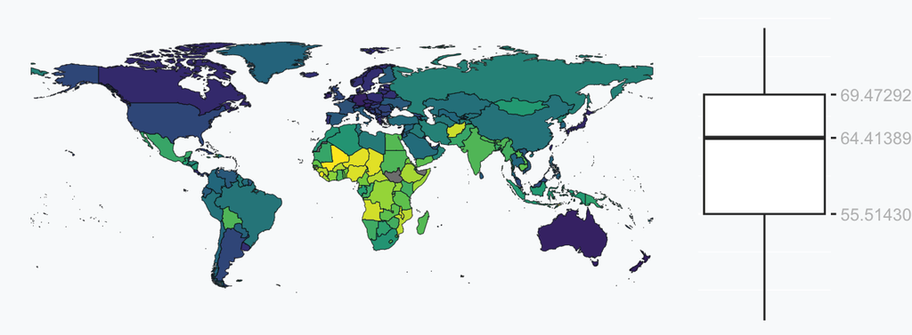

## Interquartile Maps

This is how we obtain the map:

## Interquartile Maps

These are the steps to produce the same map:

```r
clint <- classIntervals(merged$life_expectancy, style = "box")$brks
clint
```

```
[1]     -Inf 34.57637 55.51430 64.41389 69.47292 90.41084      Inf
```

## Interquartile Maps

These are the steps to produce the same map:

```r
clint <- classIntervals(merged$life_expectancy, style = "box")$brks
clint
```

```
[1]     -Inf 34.57637 55.51430 64.41389 69.47292 90.41084      Inf
```

Note the clint includes `-Inf` and `Inf`

## Interquartile Maps

These are the steps to produce the same map:

```r
clint <- classIntervals(merged$life_expectancy, style = "box")$brks
clint
```

```
[1]     -Inf 34.57637 55.51430 64.41389 69.47292 90.41084      Inf
```

Note the clint includes `-Inf` and `Inf`

## Interquartile Maps

These are the steps to produce the same map:

```r
clint <- classIntervals(merged$life_expectancy, style = "box")$brks
clint
```

```
[1]     -Inf 34.57637 55.51430 64.41389 69.47292 90.41084      Inf
```

Note the clint includes `-Inf` and `Inf`

`-Inf` and `Inf` means that the first and last intervals are open-ended.

## Interquartile Maps

These are the steps to produce the same map:

```r
clint <- classIntervals(merged$life_expectancy, style = "box")$brks
#Identifying vector length
number_values<-length(clint)
number_values
```

```
[1] 7
```

## Interquartile Maps

These are the steps to produce the same map:

```r
clint <- classIntervals(merged$life_expectancy, style = "box")$brks
#Identifying vector length
number_values<-length(clint)
```

## Interquartile Maps

An this is how we make the map:

```r
p1<-ggplot(merged, aes(fill=life_expectancy)) + geom_sf() + theme_void() +
  scale_fill_viridis_c(option = "viridis", # You can choose other options like "A", "B", or "D"
                       direction = -1,   # Use -1 for reverse color order
                       breaks = clint,
                       guide = guide_coloursteps(even.steps = FALSE,
                                                 show.limits = FALSE,
                                                 title = NULL,
                                                 barheight = unit(0.87, "npc"), # Relative to plot height
                                                 barwidth = unit(0.05, "npc"),  # Relative to plot width
                                                 label.position = "left"))



p2<- ggplot(merged, aes(life_expectancy)) + geom_boxplot() +
  scale_x_continuous(breaks = clint,
                     #labels = clint_resc,
                     position = "top") +
  coord_flip() + scale_y_continuous(labels = NULL, breaks = NULL) +
  ylab(NULL) +xlab(NULL) +
   theme(plot.margin = margin(0.1,0,0,0.1, "in"),
         axis.text = element_text(colour = "grey"),
         panel.background = element_blank())

grid.arrange(p1,p2, layout_matrix=rbind(c(1,1,1,2)))
```

## Interquartile Maps

An this is how we make the map:

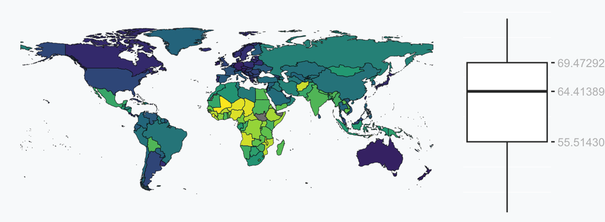

## Standard Deviation Map

- If the distribution of the data can be approximated following a normal distribution, the classification scheme can be broken into different standard deviation units

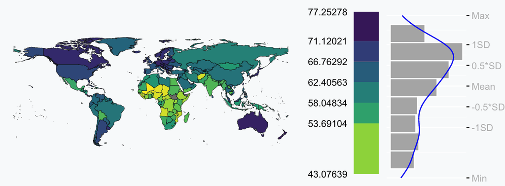

## Standard Deviation Map

This is how we make that map:

## Standard Deviation Map

This is how we make that map:

```r
#Calculating SD and Mean
life_exp_sd <- sd(merged$life_expectancy, na.rm=T)
```

## Standard Deviation Map

This is how we make that map:

```r
#Calculating SD and Mean
life_exp_sd <- sd(merged$life_expectancy, na.rm=T)
life_exp_sd
```

```
[1] 8.714583
```

## Standard Deviation Map

This is how we make that map:

```r
#Calculating SD and Mean
life_exp_sd <- sd(merged$life_expectancy, na.rm=T)
life_exp_mean <- mean(merged$life_expectancy, na.rm=T)
```

## Standard Deviation Map

This is how we make that map:

```r
#Calculating SD and Mean
life_exp_sd <- sd(merged$life_expectancy, na.rm=T)
life_exp_mean <- mean(merged$life_expectancy, na.rm=T)
life_exp_mean
```

```
[1] 62.40563
```

## Standard Deviation Map

This is how we make that map:

```r
#Calculating SD and Mean
life_exp_sd <- sd(merged$life_expectancy, na.rm=T)
life_exp_mean <- mean(merged$life_expectancy, na.rm=T)

#Creating different steps
step1<-min(merged$life_expectancy, na.rm=T)
```

## Standard Deviation Map

This is how we make that map:

```r
#Calculating SD and Mean
life_exp_sd <- sd(merged$life_expectancy, na.rm=T)
life_exp_mean <- mean(merged$life_expectancy, na.rm=T)

#Creating different steps
step1<-min(merged$life_expectancy, na.rm=T)
step1
```

```
[1] 43.07639
```

## Standard Deviation Map

This is how we make that map:

```r
#Calculating SD and Mean
life_exp_sd <- sd(merged$life_expectancy, na.rm=T)
life_exp_mean <- mean(merged$life_expectancy, na.rm=T)

#Creating different steps
step1<-min(merged$life_expectancy, na.rm=T)
step2<-life_exp_mean - life_exp_sd
```

## Standard Deviation Map

This is how we make that map:

```r
#Calculating SD and Mean
life_exp_sd <- sd(merged$life_expectancy, na.rm=T)
life_exp_mean <- mean(merged$life_expectancy, na.rm=T)

#Creating different steps
step1<-min(merged$life_expectancy, na.rm=T)
step2<-life_exp_mean - life_exp_sd
step2
```

```
[1] 53.69104
```

## Standard Deviation Map

This is how we make that map:

```r
#Calculating SD and Mean
life_exp_sd <- sd(merged$life_expectancy, na.rm=T)
life_exp_mean <- mean(merged$life_expectancy, na.rm=T)

#Creating different steps
step1<-min(merged$life_expectancy, na.rm=T)
step2<-life_exp_mean - life_exp_sd
step3<-life_exp_mean - 0.5*life_exp_sd
```

## Standard Deviation Map

This is how we make that map:

```r
#Calculating SD and Mean
life_exp_sd <- sd(merged$life_expectancy, na.rm=T)
life_exp_mean <- mean(merged$life_expectancy, na.rm=T)

#Creating different steps
step1<-min(merged$life_expectancy, na.rm=T)
step2<-life_exp_mean - life_exp_sd
step3<-life_exp_mean - 0.5*life_exp_sd
step3
```

```
[1] 58.04834
```

## Standard Deviation Map

This is how we make that map:

```r
#Calculating SD and Mean
life_exp_sd <- sd(merged$life_expectancy, na.rm=T)
life_exp_mean <- mean(merged$life_expectancy, na.rm=T)

#Creating different steps
step1<-min(merged$life_expectancy, na.rm=T)
step2<-life_exp_mean - life_exp_sd
step3<-life_exp_mean - 0.5*life_exp_sd
step4<-life_exp_mean
```

## Standard Deviation Map

This is how we make that map:

```r
#Calculating SD and Mean
life_exp_sd <- sd(merged$life_expectancy, na.rm=T)
life_exp_mean <- mean(merged$life_expectancy, na.rm=T)

#Creating different steps
step1<-min(merged$life_expectancy, na.rm=T)
step2<-life_exp_mean - life_exp_sd
step3<-life_exp_mean - 0.5*life_exp_sd
step4<-life_exp_mean
step4
```

```
[1] 62.40563
```

## Standard Deviation Map

This is how we make that map:

```r
#Calculating SD and Mean
life_exp_sd <- sd(merged$life_expectancy, na.rm=T)
life_exp_mean <- mean(merged$life_expectancy, na.rm=T)

#Creating different steps
step1<-min(merged$life_expectancy, na.rm=T)
step2<-life_exp_mean - life_exp_sd
step3<-life_exp_mean - 0.5*life_exp_sd
step4<-life_exp_mean
step5<-life_exp_mean + 0.5*life_exp_sd
```

## Standard Deviation Map

This is how we make that map:

```r
#Calculating SD and Mean
life_exp_sd <- sd(merged$life_expectancy, na.rm=T)
life_exp_mean <- mean(merged$life_expectancy, na.rm=T)

#Creating different steps
step1<-min(merged$life_expectancy, na.rm=T)
step2<-life_exp_mean - life_exp_sd
step3<-life_exp_mean - 0.5*life_exp_sd
step4<-life_exp_mean
step5<-life_exp_mean + 0.5*life_exp_sd
step5
```

```
[1] 66.76292
```

## Standard Deviation Map

This is how we make that map:

```r
#Calculating SD and Mean
life_exp_sd <- sd(merged$life_expectancy, na.rm=T)
life_exp_mean <- mean(merged$life_expectancy, na.rm=T)

#Creating different steps
step1<-min(merged$life_expectancy, na.rm=T)
step2<-life_exp_mean - life_exp_sd
step3<-life_exp_mean - 0.5*life_exp_sd
step4<-life_exp_mean
step5<-life_exp_mean + 0.5*life_exp_sd
step6<-life_exp_mean + life_exp_sd
```

## Standard Deviation Map

This is how we make that map:

```r
#Calculating SD and Mean
life_exp_sd <- sd(merged$life_expectancy, na.rm=T)
life_exp_mean <- mean(merged$life_expectancy, na.rm=T)

#Creating different steps
step1<-min(merged$life_expectancy, na.rm=T)
step2<-life_exp_mean - life_exp_sd
step3<-life_exp_mean - 0.5*life_exp_sd
step4<-life_exp_mean
step5<-life_exp_mean + 0.5*life_exp_sd
step6<-life_exp_mean + life_exp_sd
step6
```

```
[1] 71.12021
```

## Standard Deviation Map

This is how we make that map:

```r
#Calculating SD and Mean
life_exp_sd <- sd(merged$life_expectancy, na.rm=T)
life_exp_mean <- mean(merged$life_expectancy, na.rm=T)

#Creating different steps
step1<-min(merged$life_expectancy, na.rm=T)
step2<-life_exp_mean - life_exp_sd
step3<-life_exp_mean - 0.5*life_exp_sd
step4<-life_exp_mean
step5<-life_exp_mean + 0.5*life_exp_sd
step6<-life_exp_mean + life_exp_sd
step7<-max(merged$life_expectancy, na.rm=T)
```

## Standard Deviation Map

This is how we make that map:

```r
#Calculating SD and Mean
life_exp_sd <- sd(merged$life_expectancy, na.rm=T)
life_exp_mean <- mean(merged$life_expectancy, na.rm=T)

#Creating different steps
step1<-min(merged$life_expectancy, na.rm=T)
step2<-life_exp_mean - life_exp_sd
step3<-life_exp_mean - 0.5*life_exp_sd
step4<-life_exp_mean
step5<-life_exp_mean + 0.5*life_exp_sd
step6<-life_exp_mean + life_exp_sd
step7<-max(merged$life_expectancy, na.rm=T)
step7
```

```
[1] 77.25278
```

## Standard Deviation Map

This is how we make that map:

```r
#Calculating SD and Mean
life_exp_sd <- sd(merged$life_expectancy, na.rm=T)
life_exp_mean <- mean(merged$life_expectancy, na.rm=T)

#Creating different steps
step1<-min(merged$life_expectancy, na.rm=T)
step2<-life_exp_mean - life_exp_sd
step3<-life_exp_mean - 0.5*life_exp_sd
step4<-life_exp_mean
step5<-life_exp_mean + 0.5*life_exp_sd
step6<-life_exp_mean + life_exp_sd
step7<-max(merged$life_expectancy, na.rm=T)

clint <- c(step1,
           step2,
           step3,
           step4,
           step5,
           step6,
           step7)
```

## Standard Deviation Map

This is how we make that map:

```r
#Calculating SD and Mean
life_exp_sd <- sd(merged$life_expectancy, na.rm=T)
life_exp_mean <- mean(merged$life_expectancy, na.rm=T)

#Creating different steps
step1<-min(merged$life_expectancy, na.rm=T)
step2<-life_exp_mean - life_exp_sd
step3<-life_exp_mean - 0.5*life_exp_sd
step4<-life_exp_mean
step5<-life_exp_mean + 0.5*life_exp_sd
step6<-life_exp_mean + life_exp_sd
step7<-max(merged$life_expectancy, na.rm=T)

clint <- c(step1,
           step2,
           step3,
           step4,
           step5,
           step6,
           step7)
clint
```

```
[1] 43.07639 53.69104 58.04834 62.40563 66.76292 71.12021 77.25278
```

## Standard Deviation Map

This is how we make that map:

```r
#Calculating SD and Mean
life_exp_sd <- sd(merged$life_expectancy, na.rm=T)
life_exp_mean <- mean(merged$life_expectancy, na.rm=T)

#Creating different steps
step1<-min(merged$life_expectancy, na.rm=T)
step2<-life_exp_mean - life_exp_sd
step3<-life_exp_mean - 0.5*life_exp_sd
step4<-life_exp_mean
step5<-life_exp_mean + 0.5*life_exp_sd
step6<-life_exp_mean + life_exp_sd
step7<-max(merged$life_expectancy, na.rm=T)

clint <- c(min(merged$life_expectancy, na.rm=T),
           life_exp_mean - life_exp_sd,
           life_exp_mean - 0.5 *life_exp_sd,
           life_exp_mean,
           life_exp_mean + 0.5 * life_exp_sd,
           life_exp_mean + life_exp_sd,
           max(merged$life_expectancy, na.rm=T))
```

## Standard Deviation Map

This is how we make that map:

```r
#Calculating SD and Mean
life_exp_sd <- sd(merged$life_expectancy, na.rm=T)
life_exp_mean <- mean(merged$life_expectancy, na.rm=T)

#Creating different steps
step1<-min(merged$life_expectancy, na.rm=T)
step2<-life_exp_mean - life_exp_sd
step3<-life_exp_mean - 0.5*life_exp_sd
step4<-life_exp_mean
step5<-life_exp_mean + 0.5*life_exp_sd
step6<-life_exp_mean + life_exp_sd
step7<-max(merged$life_expectancy, na.rm=T)

clint <- c(min(merged$life_expectancy, na.rm=T),
           life_exp_mean - life_exp_sd,
           life_exp_mean - 0.5 *life_exp_sd,
           life_exp_mean,
           life_exp_mean + 0.5 * life_exp_sd,
           life_exp_mean + life_exp_sd,
           max(merged$life_expectancy, na.rm=T))
clint
```

```
[1] 43.07639 53.69104 58.04834 62.40563 66.76292 71.12021 77.25278
```

## Standard Deviation Map

This is how we make that map:

```r
#Calculating SD and Mean
life_exp_sd <- sd(merged$life_expectancy, na.rm=T)
life_exp_mean <- mean(merged$life_expectancy, na.rm=T)

#Creating different steps
clint <- c(min(merged$life_expectancy, na.rm=T),
           life_exp_mean - life_exp_sd,
           life_exp_mean - 0.5 *life_exp_sd,
           life_exp_mean,
           life_exp_mean + 0.5 * life_exp_sd,
           life_exp_mean + life_exp_sd,
           max(merged$life_expectancy, na.rm=T))

#Identifying vector length
number_values<-length(clint)
```

## Standard Deviation Map

This is how we make that map:

```r
#Calculating SD and Mean
life_exp_sd <- sd(merged$life_expectancy, na.rm=T)
life_exp_mean <- mean(merged$life_expectancy, na.rm=T)

#Creating different steps
clint <- c(min(merged$life_expectancy, na.rm=T),
           life_exp_mean - life_exp_sd,
           life_exp_mean - 0.5 *life_exp_sd,
           life_exp_mean,
           life_exp_mean + 0.5 * life_exp_sd,
           life_exp_mean + life_exp_sd,
           max(merged$life_expectancy, na.rm=T))

#Identifying vector length
number_values<-length(clint)
number_values
```

```
[1] 7
```

## Standard Deviation Map

This is how we make that map:

```r
p1<-ggplot(merged, aes(fill=life_expectancy)) + geom_sf() + theme_void() +
  scale_fill_viridis_c(option = "viridis", # You can choose other options like "A", "B", or "D"
                       direction = -1,   # Use -1 for reverse color order
                       breaks = clint,
                       guide = guide_coloursteps(even.steps = FALSE,
                                                 show.limits = FALSE,
                                                 title = NULL,
                                                 barheight = unit(0.87, "npc"), # Relative to plot height
                                                 barwidth = unit(0.05, "npc"),  # Relative to plot width
                                                 label.position = "left"))
```

## Standard Deviation Map

This is how we make that map:

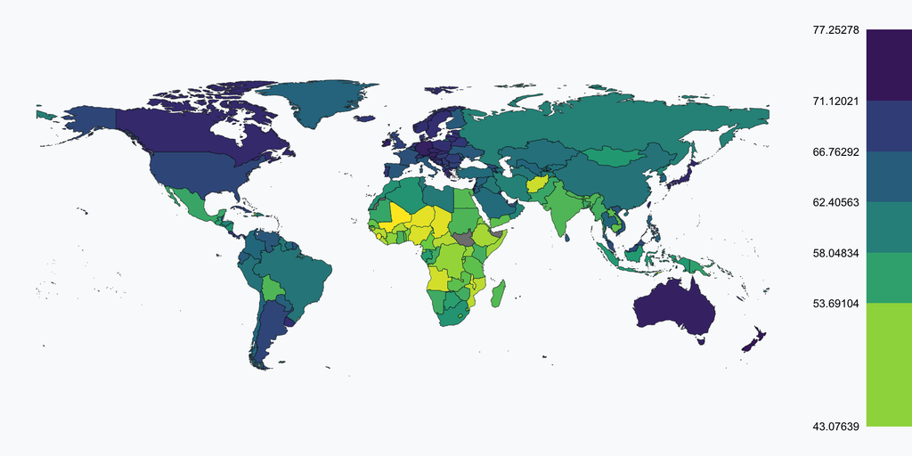

## Standard Deviation Map

This is how we make that map:

```r
p2<- ggplot(merged, aes(life_expectancy)) +
  geom_histogram(aes(y = after_stat(density)), bins = 10,
                 fill = "grey70",
                 col = "white")+
  coord_flip() +
  geom_density(colour = "blue")+
  scale_x_continuous(breaks = clint,
                     labels = c("Min", "-1SD" , "-0.5*SD", "Mean", "0.5*SD", "1SD", "Max"),
                     position = "top", limits = range(clint)) +
 scale_y_continuous(labels = NULL, breaks = NULL) +
  ylab(NULL) +xlab(NULL) +
   theme(plot.margin = margin(0.1,0,0,0.1, "in"),
         axis.text = element_text(colour = "grey"),
         panel.background = element_blank())
```

## Standard Deviation Map

This is how we make that map:

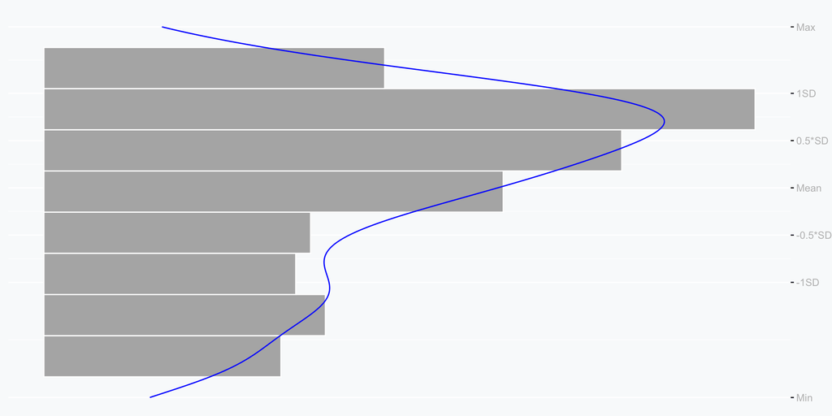

## Standard Deviation Map

This is how we make that map:

````markdown
```{r , fig.width = 6.5, fig.height=2.4}
library(gridExtra)
#Arranging the Map and Histogram together
grid.arrange(p1,p2, layout_matrix=rbind(c(1,1,1,2)))
```
````

## Standard Deviation Map

This is how we make that map:

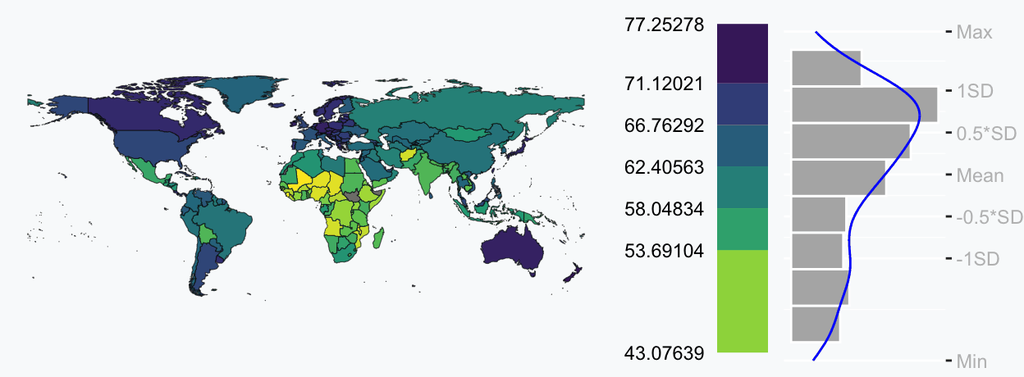

## Outlier Maps

- So far we looked at the entire distribution of values
- However, we may want to place emphasis on extreme values
- We can produce outlier maps with
  - Boxplot
  - Standard deviation
  - Quantiles

## Outlier Maps

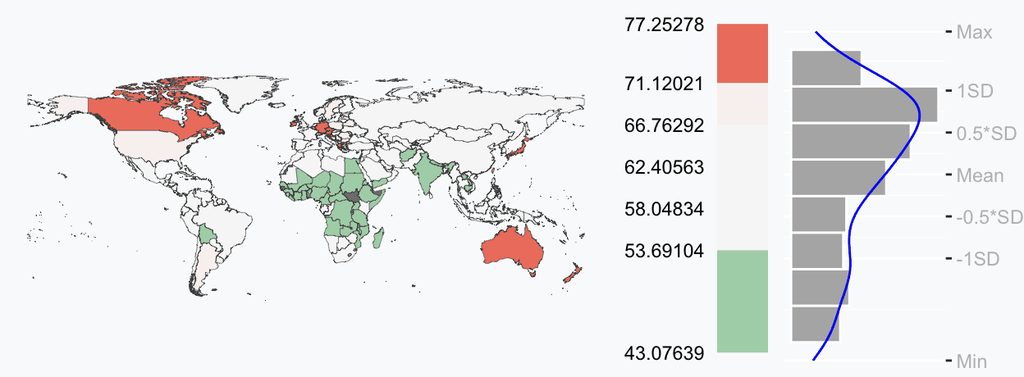

## Outlier Maps

Or even better:

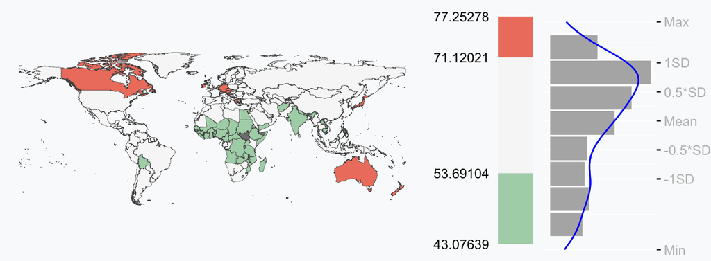

## Outlier Maps

This is how we obtain that map:

## Outlier Maps

This is how we obtain that map:

```r
life_exp_sd <- sd(merged$life_expectancy, na.rm=T)
life_exp_mean <- mean(merged$life_expectancy, na.rm=T)

clint <- c(min(merged$life_expectancy, na.rm=T),
           life_exp_mean - life_exp_sd,
           life_exp_mean - 0.5 *life_exp_sd,
           life_exp_mean,
           life_exp_mean + 0.5 * life_exp_sd,
           life_exp_mean + life_exp_sd,
           max(merged$life_expectancy, na.rm=T))
```

## Outlier Maps

This is how we obtain that map:

```r
life_exp_sd <- sd(merged$life_expectancy, na.rm=T)
life_exp_mean <- mean(merged$life_expectancy, na.rm=T)

clint <- c(min(merged$life_expectancy, na.rm=T),
           life_exp_mean - life_exp_sd,
           life_exp_mean - 0.5 *life_exp_sd,
           life_exp_mean,
           life_exp_mean + 0.5 * life_exp_sd,
           life_exp_mean + life_exp_sd,
           max(merged$life_expectancy, na.rm=T))
clint
```

```
[1] 43.07639 53.69104 58.04834 62.40563 66.76292 71.12021 77.25278
```

## Outlier Maps

This is how we obtain that map:

```r
life_exp_sd <- sd(merged$life_expectancy, na.rm=T)
life_exp_mean <- mean(merged$life_expectancy, na.rm=T)

clint <- c(min(merged$life_expectancy, na.rm=T),
           life_exp_mean - life_exp_sd,
           life_exp_mean - 0.5 *life_exp_sd,
           life_exp_mean,
           life_exp_mean + 0.5 * life_exp_sd,
           life_exp_mean + life_exp_sd,
           max(merged$life_expectancy, na.rm=T))

#Making the breaks
breaks_int = clint[c(1, 2, 6,7)]
```

## Outlier Maps

This is how we obtain that map:

```r
life_exp_sd <- sd(merged$life_expectancy, na.rm=T)
life_exp_mean <- mean(merged$life_expectancy, na.rm=T)

clint <- c(min(merged$life_expectancy, na.rm=T),
           life_exp_mean - life_exp_sd,
           life_exp_mean - 0.5 *life_exp_sd,
           life_exp_mean,
           life_exp_mean + 0.5 * life_exp_sd,
           life_exp_mean + life_exp_sd,
           max(merged$life_expectancy, na.rm=T))

#Making the breaks
breaks_int = clint[c(1, 2, 6,7)]
breaks_int
```

```
[1] 43.07639 53.69104 71.12021 77.25278
```

## Outlier Maps

This is how we obtain that map:

```r
life_exp_sd <- sd(merged$life_expectancy, na.rm=T)
life_exp_mean <- mean(merged$life_expectancy, na.rm=T)

clint <- c(min(merged$life_expectancy, na.rm=T),
           life_exp_mean - life_exp_sd,
           life_exp_mean - 0.5 *life_exp_sd,
           life_exp_mean,
           life_exp_mean + 0.5 * life_exp_sd,
           life_exp_mean + life_exp_sd,
           max(merged$life_expectancy, na.rm=T))

#Making the breaks
breaks_int = clint[c(1, 2, 6,7)]
breaks_int
```

```
[1] 43.07639 53.69104 71.12021 77.25278
```

This is how it compares to `clint`:

```r
clint
```

```
[1] 43.07639 53.69104 58.04834 62.40563 66.76292 71.12021 77.25278
```

## Outlier Maps

This is how we obtain that map:

```r
p3 <- ggplot(merged, aes(fill=life_expectancy)) +
  geom_sf(linewidth=0.1, color="grey30") +
  theme_void() +
  scale_fill_stepsn(colors = c("#1A9850",
                               "#f7f7f7", "#f7f7f7","#f7f7f7",
                               "#D73027") ,
                    breaks = breaks_int,
                       guide = guide_coloursteps(even.steps = FALSE,
                                                 show.limits = FALSE,
                                                 title = NULL,
                                                 barheight = unit(0.87, "npc"), # Relative to plot height
                                                 barwidth = unit(0.05, "npc"),  # Relative to plot width
                                                 label.position = "left"))
```

## Outlier Maps

This is how we obtain that map:

```r
p4<- ggplot(merged, aes(life_expectancy)) +
  geom_histogram(aes(y = after_stat(density)), bins = 10,
                 fill = "grey70",
                 col = "white")+
  coord_flip() +
  geom_density(colour = "blue")+
  scale_x_continuous(breaks = clint,
                     labels = c("Min", "-1SD" , "-0.5*SD", "Mean", "0.5*SD", "1SD", "Max"),
                     position = "top", limits = range(clint)) +
 scale_y_continuous(labels = NULL, breaks = NULL) +
  ylab(NULL) +xlab(NULL) +
   theme(plot.margin = margin(0.1,0,0,0.1, "in"),
         axis.text = element_text(colour = "grey"),
         panel.background = element_blank())
```

## Outlier Maps

This is how we obtain that map:

```r
grid.arrange(p3,p4, layout_matrix=rbind(c(1,1,1,2)))
```

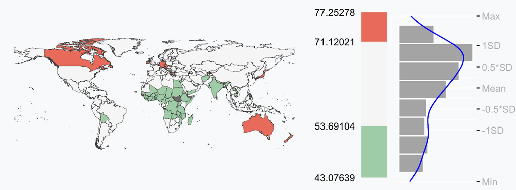

## What Have We Learned?

In this lecture we learned how to map:

- points
- lines
- polygons

We also learned how to make choropleth maps of different types:

- with histograms
- quantile maps
- interquartile maps
- standard deviation maps
- outlier maps